```python
import math
import scipy
import numpy as np
import matplotlib.pyplot as pyplot
from scipy.sparse import coo_matrix, csc_matrix
from scipy.sparse.linalg import lsqr
```

# Task 1: Constructing the weight matrix

Similiar solutions. However the sample solution selects the bins in a more elegant way using also the np.ceil function. Also iterating over the alphas is done using a for loop. However, they also use the scipy.sparse.coo_matrix for the assemvble of the matrix.

```python
'''function X = construct_X(M, alphas, Np = None) which, given the desired tomogram size(M) D = M × M, a list of measurement
angles (α0, α1, . . .) (in degrees) and an optional sensor resolution Np, returns the matrix X, which completely describes
the setup of our simplified CT scanner.'''

def construct_X(M, alphas, Np = None):
    #If Np is not given, choose a value large enough to the diagonal of the image β, like Np = √2 · M
    if Np is None:
        Np = int(np.ceil(np.sqrt(2)*M))
    if Np % 2 == 0:
        Np = Np - 1
    print (f"Np={Np}")

    # Tomogram size of D = M*M
    D = M*M
    #intensities measured at No projection angles
    No = len(alphas)
    # response vector N of size Np * No
    N = Np * No

    a0 = - (M -1)/2
    b0 = - (M - 1)/2
    s0 = (Np - 1)/ 2
    ja = np.mgrid[0:D] % M
    jb = np.mgrid[0:D] // M
    C = np.stack((a0 + ja, b0 + jb))

    #i_index is the row indices of matrix X
    i_index = []

    #j_index is the column indices of matrix X
    j_index = []

    #weights of Xij matrix
    weights = []

    for alpha_index in range(No):
        alpha =  alphas[alpha_index]
        n = np.array([np.cos(np.deg2rad(alpha)), np.sin(np.deg2rad(alpha))])
        p = np.dot(n.T, C) + s0

        j_index.extend(ja + M * jb)
        i_index.extend((p//1)+ alpha_index * Np)
        weights.extend(1-(p%1))
        j_index.extend(ja + M * jb)
        i_index.extend(((p+1)//1)+ alpha_index*Np)
        weights.extend(p%1)

    X = coo_matrix((weights, (i_index, j_index)), shape = (N, D), dtype = np.float32)
    return X
```

The solution is flipped verticaly. Otherwise essentially the same solution.

```python
own_weights = construct_X(10, [-33, 1, 42])
sample_weights = np.load("D:/Downloads/X_example.npy")
```

```
Np=15
```

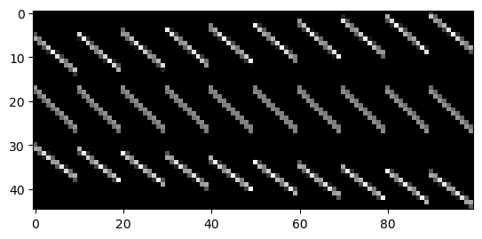

```python
pyplot.imshow(own_weights.toarray(), cmap="gray")
```

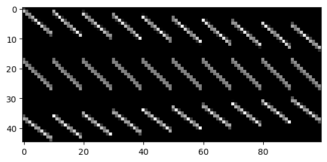

```python
pyplot.imshow(sample_weights, cmap="gray")
```

# Task 2: Recovering the image

```python
small_y = np.load("D:/Downloads/y_77.npy")
small_alphas = np.load("D:/Downloads/alphas_77.npy")

small_weights = construct_X(77, small_alphas)
sparsity = 1.0 - small_weights.nnz / (small_weights.shape[0] * small_weights.shape[1])
print("Sparsity of generated table: %.2f percent." % (100.0 * sparsity))
```

```
Np=109
Sparsity of generated table: 98.17 percent.
```

The solution is flipped verticaly. Otherwise essentially the same solution.

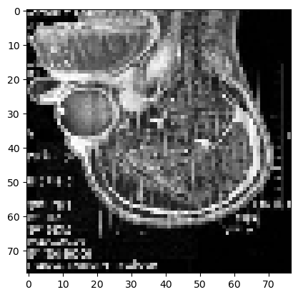

```python
image = lsqr(small_weights, small_y)
pyplot.imshow(image[0].reshape((77, 77)), cmap="gray")
```

```python
big_y = np.load("D:/Downloads/y_195.npy")
big_alphas = np.load("D:/Downloads/alphas_195.npy")

big_weights = construct_X(195, big_alphas)
sparsity = 1.0 - big_weights.nnz / (big_weights.shape[0] * big_weights.shape[1])
print("Sparsity of generated table: %.2f percent." % (100.0 * sparsity))
```

```
Np=275
Sparsity of generated table: 99.27 percent.
```

The solution is flipped verticaly. Otherwise essentially the same solution.

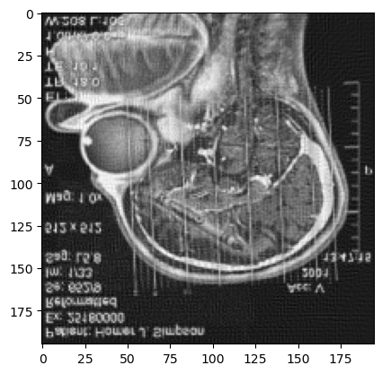

```python
image = lsqr(big_weights, big_y, atol=1e-05, btol=1e-05)
pyplot.imshow(image[0].reshape((195, 195)), cmap="gray")
```

As seen in this image, the headache was caused by a pen inside the patient's head.

# Task 3: Minimizing the radiation dose

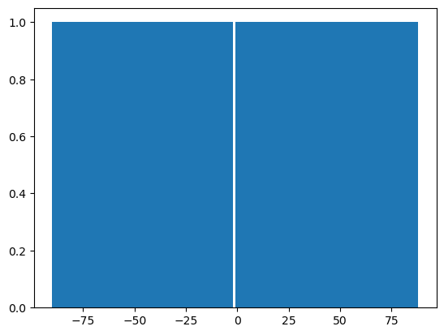

```python
pyplot.hist(big_alphas, bins=180)
pyplot.show()
```

As shown in the graph, the scan angles in the provided data set are spread very evenly between -90 and 90 degrees. Since similar angles will yield a very similar result, the most natural approach to reducing the radiation dose would be to evenly thin out the scans - e.g. by only taking every second, third, or fourth measurement.

The solution is flipped verticaly. Otherwise essentially the same solution. However, not as many examples were given.

```
Np=275
```

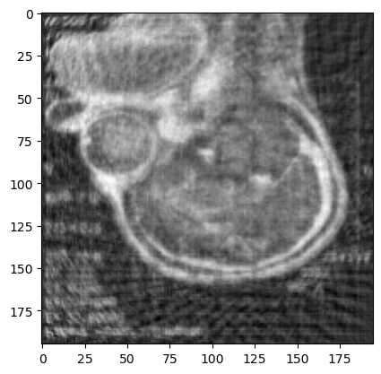

```python
reduction_factor = 5

big_alphas_reduced = big_alphas[big_alphas % reduction_factor == 0]
big_y_reduced = big_y[np.repeat(big_alphas % reduction_factor == 0, 275)]

big_weights_reduced = construct_X(195, big_alphas_reduced)
image = lsqr(big_weights_reduced, big_y_reduced, atol=1e-05, btol=1e-05)
pyplot.imshow(image[0].reshape((195, 195)), cmap="gray")
```

While the head can still be identified with only 20% of the original radiation dose, the cause can no longer be determined here.

Roughly the same solution. However, one could reduce the angles even further.

```
Np=275
```

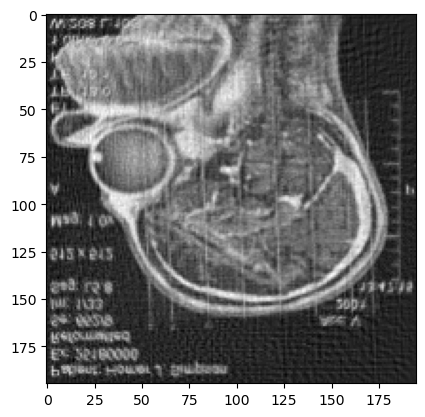

```python
reduction_factor = 2

big_alphas_reduced = big_alphas[big_alphas % reduction_factor == 0]
big_y_reduced = big_y[np.repeat(big_alphas % reduction_factor == 0, 275)]

big_weights_reduced = construct_X(195, big_alphas_reduced)
image = lsqr(big_weights_reduced, big_y_reduced, atol=1e-05, btol=1e-05)
pyplot.imshow(image[0].reshape((195, 195)), cmap="gray")
```

With a reduction of 50%, the cause of the injury can still barely be identified. Any further reduction would probably leave the image unidentifiable.